# Raport4

Amelia Olejniczak

2024-04-19

# 1 Wprowadzenie

Ten raport dotyczy badania średnich wyników na trzech różnych płaszczyznach (oceny, test IQ oraz test psychologiczny) uczniów klas siódmych. Została wylosowana próba 89 uczniów i na jej podstawie wyliczymy średnie wyniki oraz oszacujemy je dla wszystkich uczniów klas siódmych. Porównamy także, jak wyniki się prezentują dla chłopców, a jak dla dziewcząt w tym wieku.

Warto jednak zauważyć, że zebrane dane są niekompletne. Brakuje m.in. numerów 23, 42 czy 75, co daje nam łączną wielkość próby 78. Nie robi to wielkiej różnicy w badaniach, gdyż dalej może to być próba reprezentująca wszystkich uczniów. Jest również wystarczająco dużo przebadanych dziewcząt i chłopców (odpowiednio 32 oraz 46, potrzebujemy co najmniej 30) aby móc wnioskować o wszystkich uczniach.

# 2 Analiza średniej ocen

## 2.1 Analiza próby

Analizę średniej ocen rozpocznę od przebadania samej próby. Jej średnia wynosi około 7.45, a odchylenie standardowe około 2.1, więc nie jest to bardzo zróżnicowana próba, szczególnie patrząc na to, że mediana wynosi 7.83, zatem jest bardzo zbliżona do średniej. Największa średnia ocen w tej próbie wynosi 10.76, a najmniejsza 0.53, zatem jest dość duży rozrzut między tymi wartościami.

Na podstawie tych informacji, możemy oszacować, ile wynosi średnia dla całej populacji, korzystając z rozkładu t Studenta z 77 stopniami swobody. Dla próby mającej powyżej 30 elementów możemy przybliżyć średnią rozkładem normalnym. Jednak ponieważ nie znamy odchylenia standardowego dla całej populacji, przy wyznaczaniu przedziału ufności należy skorzystać z rozkładu t-Studenta.

W takim przypadku 95% przedział ufności to [6.97, 7.92], zatem najprawdopodobniej w tym przedziale znajduje się średnia wszystkich uczniów klas siódmych. Ma on długość 0.95. Nie jest to więc duży przedział.

Przyjrzymy się teraz histogramowi dla średniej ocen badanej losowej próby, zakładając, że może być reprezentatywna dla wszystkich uczniów klasy siódmej.

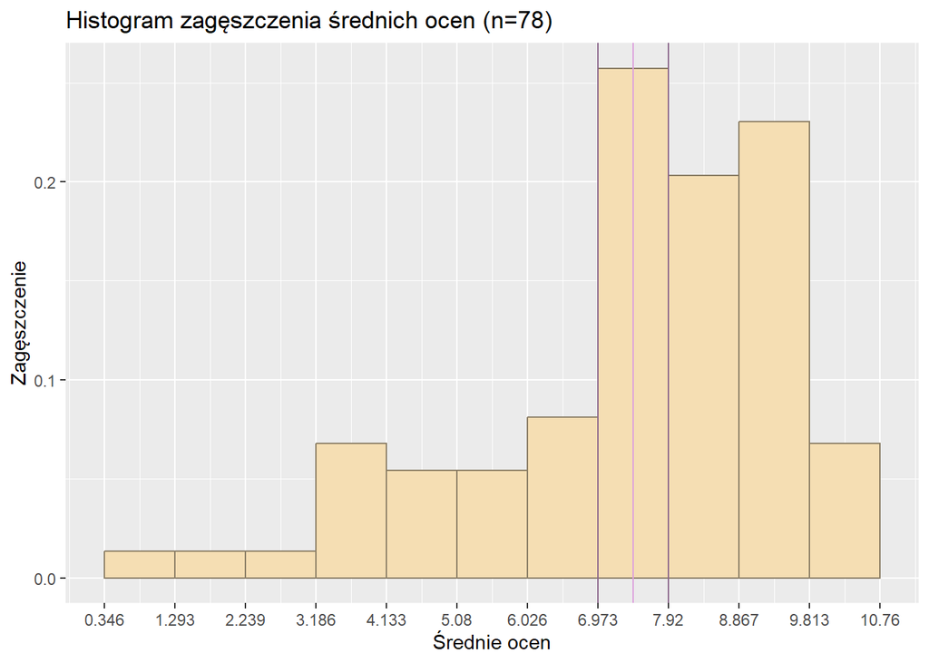

Bazując na tym wykresie można stwierdzić, że znaczna większość wartości znajduje się wśród wyższych średnich, z kolei jedynie pojedyncze osoby znajdują się poniżej średniej 3. Może to być spowodowane “przepychaniem” przez nauczycieli słabszych uczniów do wyższych klas, aby na pewno ukończyli chociaż szkołę średnią lub zwyczajną ambicją uczniów, którym zależy na wysokich wynikach w nauce. Średnia wynosząca między 7 a 8 jest również dość wysoka w przypadku skali do 11, co również świadczy o tym, że uczniom (lub czasem ich rodzicom) może zależeć na dobrych wynikach w nauce.

## 2.2 Analiza ocen zależna od płci

Jeśli spojrzymy na chłopców i dziewczęta oddzielnie można zauważyć pewne zależności. Średnia ocen chłopców wynosi 7.28 (mediana - 7.88), a dziewcząt 7.68 (mediana - 7.83), zatem zarówno obie mediany są do siebie zbliżone, jak i obie średnie są do siebie podobne. Mimo wszystko jednak dziewczyny mają tę średnią wyższą, chociaż chłopcy mają wyższą medianę. Odchylenie standardowe dziewcząt wynosi 1.69, a chłopców 2.34. To odchylenie standardowe wskazuje na to, że dziewczęta mają bardziej zbliżone do siebie wyniki, a chłopcy mają wyniki bardziej zróżnicowane.

Co ciekawe, zarówno największa, jak i najmniejsza wartość próby znajduje się wśród chłopców, ale różnica między najmniejszymi wartościami dziewczynek i chłopców jest dużo większa niż różnica między największymi wartościami w tych grupach. Najmniejsza wartość u dziewczynek to 3.408 (różnica 2.878), a największa 10.7 (różnica 0.06). Może to również wskazywać na fakt, że częściej dziewczynki mają wyższe średnie niż chłopcy i nawet gdy sobie nie radzą bardzo dobrze, bardziej się starają osiągać nieco lepsze wyniki.

onownie policzę przedziału ufności, tym razem z podziałem na płcie. 95% przedział ufności dla chłopców wynosi [6.59, 7.98], a dla dziewczyn [7.07, 8.29]. Długość tych przedziałów wynosi 1.39 dla chłopców i 1.22. Bazując na tym można stwierdzić, że dziewczyny mają średnio nieco wyższe oceny niż chłopcy. Oba przedziały mają jednak część wspólną. Wynosi ona od 7.07 do 7.98. Jest więc pewna szansa, że średnie ich ocen byłyby bardzo zbliżone do siebie.

Przyjrzę się teraz histogramowi gęstości dla chłopców i dziewcząt, aby zobaczyć, w jaki sposób rozkładają się średnie dla konkretnych płci.

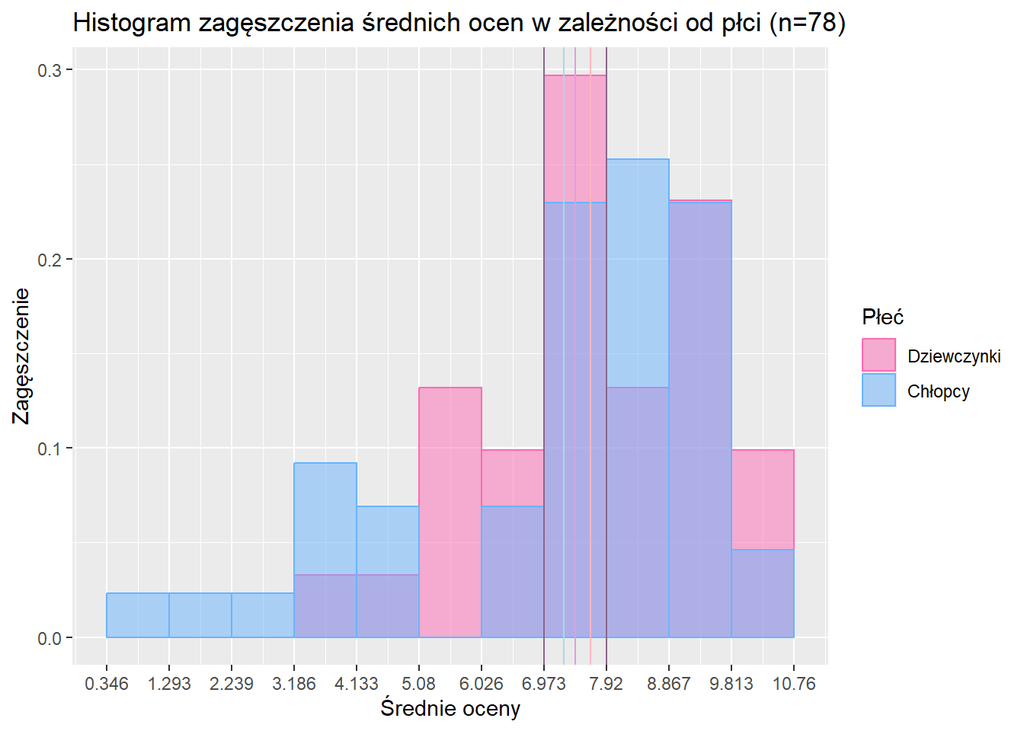

Na pierwszy rzut oka widać, że wszystkie wartości poniżej średniej 3 były średnimi ocen chłopców, z czego najpewniej wynika tak duże odchylenie standardowe próby. Mimo że większy procent dziewcząt jest wśród najwyższych wyników, to największy słupek chłopców jest dla wartości między 7.920, a 8.867, podczas gdy dziewcząt dla wartości między 6.973 i 7.920. Wyższe wyniki dziewcząt wynikają najpewniej z faktu, że częściej dziewczynki niż chłopcy mają wyniki wśród najwyższych wartości, ale to częściej chłopcy niż dziewczynki mają z kolei bardzo niskie średnie ocen. Ale to dziewczynki w tej próbie częściej były “przeciętne” - między 5.08, a 7.92.

Ciekawym jest fakt, że u chłopców wartości są bardziej rozrzucone, zatem równie często znajdują się jednostki uczące się bardzo dobrze, jak i te uczące się fatalnie. U dziewczyn te wyniki są o wiele bardziej “zbite”.

# 3 Analiza testu IQ

Przy analizie IQ uczniów sugeruję się pewnymi znanymi faktami. Wiadomo, że rozkład ilorazu inteligencji może być przybliżony rozkładem normalnym. Za przeciętne IQ uznaje się wtedy wynik między 85 a 115 punktów i to taką interpretacją będę się posługiwać przy analizie wyników.

## 3.1 Analiza próby

W przypadku testu IQ średnia wynosi około 109, a mediana 110, zatem jest to przeciętny wynik. Minimalny wynik wynosi 72, a maksymalny 136 zatem w próbie mamy do czynienia zarówno z jednostkami z bardzo wysoką inteligencją, jak i takimi z niskim jej poziomem. Próbkowe odchylenie wyników tego testu wynosi 13.17.

Na podstawie tych informacji można podać przedział ufności. Średnie IQ wszystkich uczniów klas siódmych mieści się w przedziale [105.95, 111.89] z 95% prawdopodobieństwem. Ma on długość 5.94, zatem ponownie nie jest to duży przedział.

W następnej kolejności zajmę się analizą histogramu.

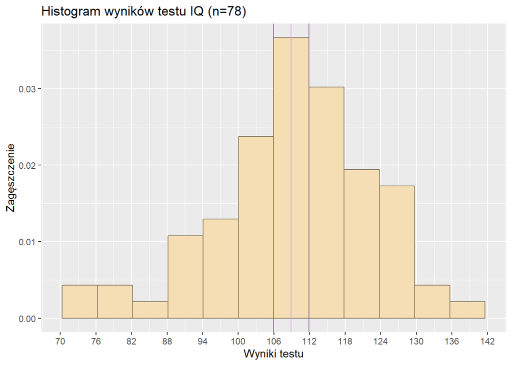

Jest on dość symetryczny, widać, że największy słupek stanowi średni wynik IQ, a osób z bardzo wysokim, jak i bardzo niskim wynikiem testu jest niewiele. Wydaje się, jakby było więcej osób powyżej przeciętnej (>115), niż poniżej przeciętnej (<85), co może być spowodowane faktem, że jesteśmy w grupie osób uczących się. Osoby w siódmej klasie miały nieco czasu na wyuczenie umiejętności logicznego myślenia, zatem można założyć, że to może wpływać na widoczne wyniki. Gdybyśmy sprawdzili grupę osób z różnym wykształceniem, mogłyby być nieco bardziej różnorodne. Mimo wszystko, są to wyniki bardzo zbliżone do rozkładu normalnego, który, jak wiemy, jest rozkładem IQ w społeczeństwie.

## 3.2 Analiza IQ zależna od płci

Tutaj również największa wartość próby jest ilorazem inteligencji chłopca, jednak najmniejsza należy już do dziewczyny. Najwyższe IQ dziewcząt wynosi 132 (różnica 4), a najniższe IQ chłopaka 77 (różnica 5), zatem oba wyniki są bardzo do siebie zbliżone i należą do tej samej grupy w przypadku badania ilorazu inteligencji (bardzo wysokie lub niskie).

95% przedział ufności dla dziewcząt wynosi [100.31, 110.56] (długość - 10.25), a dla chłopców [107.8, 114.9] (długość - 7.1). U dziewcząt jest to przedział przeciętny, natomiast u chłopców zbliża się do 115 z prawej strony, zatem jest o wiele bliżej ponadprzeciętnego IQ. Wciąż, jest jednak możliwość, że wśród wszystkich uczniów klasy siódmej średnie chłopców i dziewcząt są równe lub bardzo do siebie zbliżone.

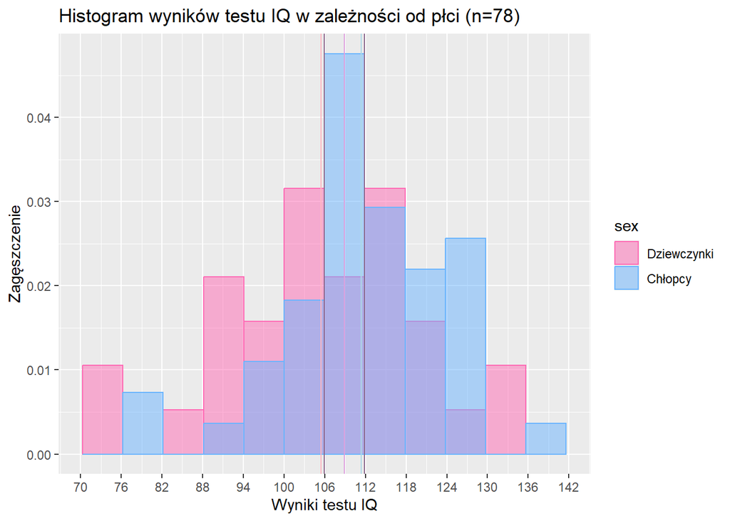

# 4 Analiza testu psychologicznego

Test psychologiczny (Piers-Harris Children’s Self-Concept Scale) bada uczniów w sześciu kategoriach (dopasowanie behawioralne, status intelektualny i szkolny, wygląd fizyczny, stan niepokoju oraz szczęście i satysfakcja). Test ma na celu wskazanie jak uczeń postrzega m.in. swoje możliwości do osiągnięcia akademickich sukcesów, a także przede wszystkim, jak dobrze postrzega samego siebie. Wyniki powyżej 70 są uznawane za bardzo wysokie, powyżej 60 za wysokie, przeciętne są w kategorii od 40 do 59, niski dla poniżej 39 i bardzo niski dla 29. Zarówno bardzo wysokie jak i bardzo niskie wyniki mogą być niepokojące.

## 4.1 Analiza próby

Średnia próby jeśli chodzi o wyniki testu wynosi 56.96, zatem należy do przeciętnych wyników, ale w górnej granicy, bardzo zbliżając się do wyników wysokich. Świadczy to dobrze o uczniach, ponieważ wskazuje na fakt, że mają wysoką wiarę w siebie oraz swoje możliwości. Mają pozytywne podejście do siebie. Podobnie mediana wynosi 59.5, więc jest wyższa nawet od średniej. Odchylenie standardowe wynosi 12.41. Najwyższy wynik testu wyniósł 80, a najmniejszy 20, zatem mamy zarówno jednostki z bardzo wysokimi wynikami, jak i bardzo niskimi. Może to być niepokojące i warto się tym jednostkom przyjrzeć bliżej.

W następnej kolejności przyjrzę się histogramowi.

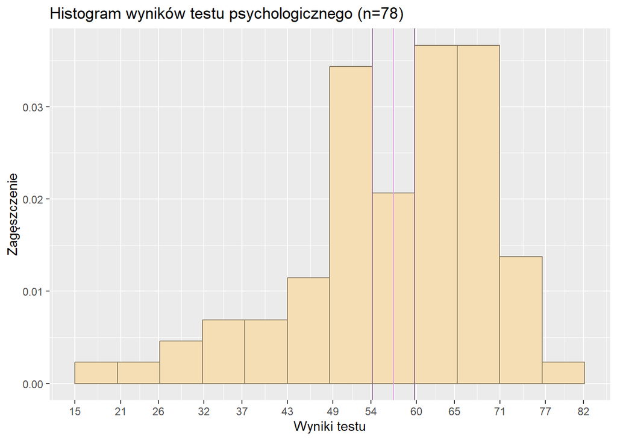

Mimo, że średnia wynosi około 57 punktów to widać, że w słupku wyznaczonym przez przedział ufności znajduje się dość mało osób. Znacznie więcej jest w słupkach obok - między 49 i 54, jak i między 60 i 65. Prawdopodobnie równomierne ich rozłożenie w tych miejscach powoduje taką średnią. Dużo więcej uczniów daje bardzo wysokie oceny niż bardzo niskie (osób powyżej 70 punktów wydaje się być dużo więcej niż osób poniżej 29), zatem można założyć, że uczniowie klas siódmych mają raczej wysokie poczucie własnej wartości. Potwierdza to również fakt, że dwa najwyższe słupki wyznaczają wartości powyżej 60. Jest to dobry znak.

## 4.2 Analiza testu psychologicznego dla płci

W przypadku testu psychologicznego średni wynik dla dziewcząt w próbie wyniósł 55.69, a dla chłopców 57.85. Znów, podobnie jak w przypadku IQ, chłopcy mają średnie wyniki lepsze od dziewczyn. Odchylenie standardowe dziewczyn i chłopców wynosi kolejno 12.53 oraz 12.39, zatem jest bardzo do sibeie zbliżone i tym razem to u chłopców dane są bardziej “zbite”, jednak różnica jest bardzo niewielka.

Podobnie, jak w przypadku ocen to u chłopców znajdują się wartość największa i najmniejsza całej próby. U dziewcząt najmniejsza wartość wynosi 21 (różnica - 1), a największa 72 (różnica - 8. Najmniejsze wartości są bardzo do siebie zbliżone, natomiast największe są bardziej od siebie oddalone.

Na podstawie powyższych informacji można obliczyć 95% przedziały ufności. Dla dziewcząt wynosi on [51.17, 60.2] (długość - 9.03), a u chłopców [54.17, 61.53] (długość - 7.36). Ponownie, przedział chłopców kończy się nieco dalej, więc można założyć, że średni wynik testu u chłopców jest nieco większy. Przedziały mają jednak część wspólną, więc nie można wykluczyć sytuacji, w której średnie te są równe.

Teraz przyjrzymy się histogramowi próby.

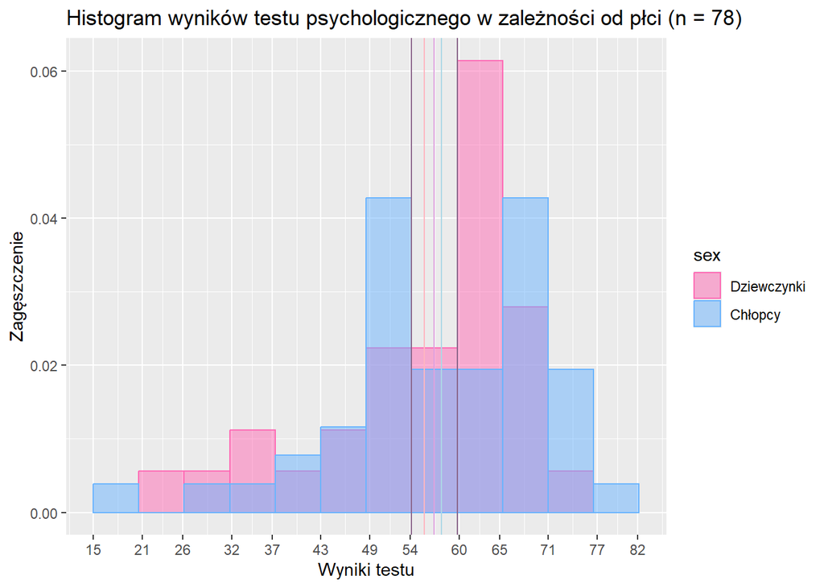

# 5 Analiza zależności między zmiennymi

Sprawdzę teraz zależności między zmiennymi. Wykonam histogramy dla różnych zmiennych w zależności od innych zmiennych (np. jak dla średnich ocen w grupach 0-3, 3-6, 6-9 i 9-11 rozkłada się IQ). Wykonam wykresy jedynie w jedną stronę bo wnioski w drugą będą najpewniej takie same (np. jedynie wykres pokazujących jak rozkłada się IQ wśród średnich, a nie odwrotnie).

## 5.1 Zależność IQ od średniej ocen

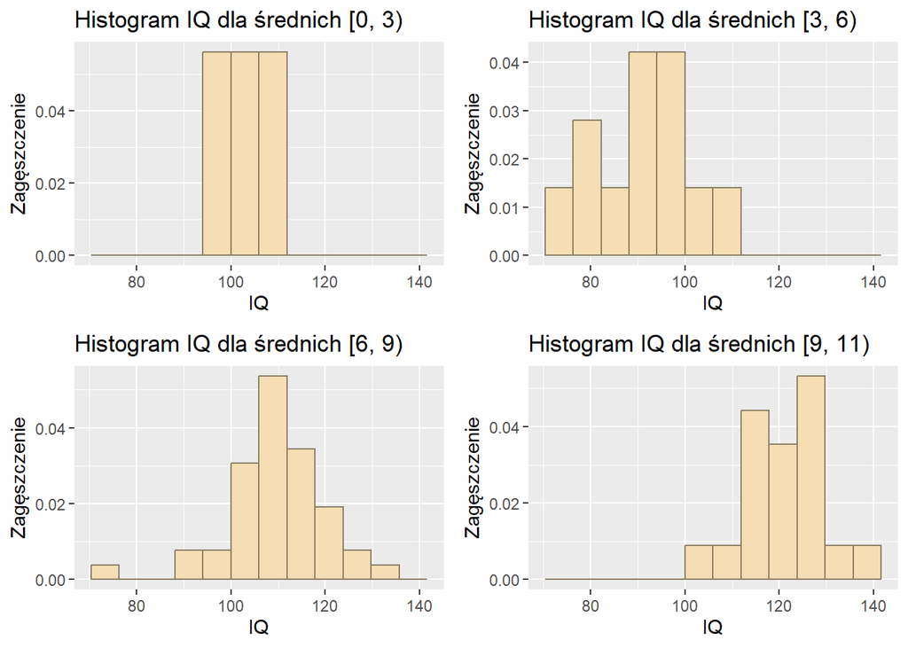

## 5.2 Zależność testu psychologicznego od średniej ocen

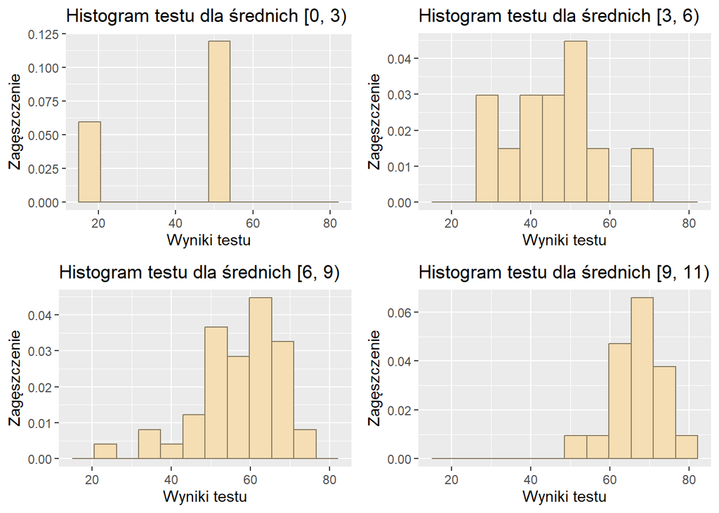

Tym razem na powyższych wykresach można zauważyć, że im wyższa średnia, tym wyższe wyniki testu psychologicznego. Wykres coraz bardziej przesuwa się w prawą stronę, chociaż najmniejsza próba jest na tyle niewielka, że trudno jest jednoznacznie stwierdzić, jak to wygląda dla większej liczby osób. Jednak na pozostałych trzech wykresach jest zdecydowanie widoczne, jak z każdą kolejną średnią ocen przesuwa się nieco w prawo. Można więc założyć, że oceny wpływają na wiarę w siebie wśród uczniów.

## 5.3 Zależność IQ od testu psychologicznego

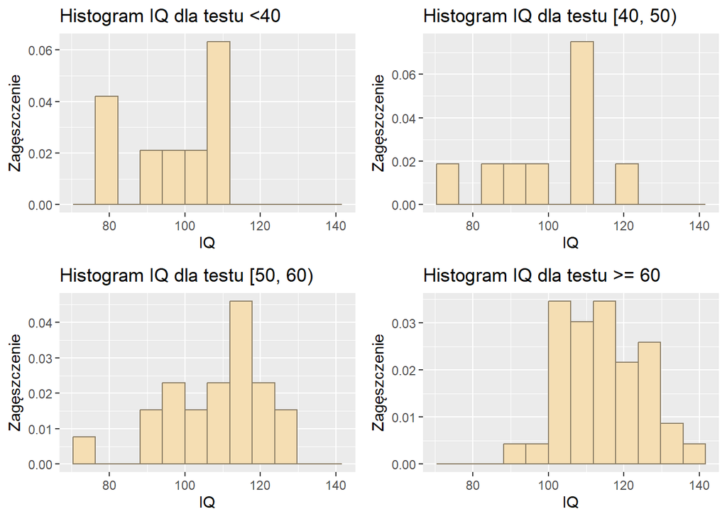

Osoby z niskim wynikiem testu niekoniecznie mają niskie IQ, podobnie osoby ze średnim wynikiem testu są bardzo rozproszone po całym przedziale (zarówno wysokie, jak i bardzo niski wynik testu IQ). Jednak osoby z bardzo wysokim IQ pojawiają się jedynie na ostatnim wykresie. Zatem mimo że w pozostałych przypadkach nie ma żadnych powiązań, to Jeśli osoba miała bardzo wysoki wynik testu IQ to miała również wysoki wynik testu psychologicznego.

# 6 Podsumowanie

Z badanej próby siódmoklasistów wynika, że uczniowie mają raczej dobre oceny i ich wyniki testów, zarówno psychologicznych, jak i IQ są wśród górnej granicy wyników przeciętnych. Warto zwrócić uwagę na fakt, że mimo że dziewczyny uczą się delikatnie lepiej, to chłopcy mają lepsze wyniki obu testów. Warto zwrócić uwagę na to, że mimo wszystko częściej chłopcy lądowali w skrajnych przypadkach, a dziewczęta miały bardziej zbliżone do siebie wyniki.